# Optics: Lenses and Mirrors — Teacher Guide

## Cover

**Unit: Waves — Lesson 09: Optics (Lenses and Mirrors)** East Meadow Schools × Valley Stream Central High School District Strategy chips: ACTIVE LEARNING

## Curated Resources (from East Meadow Scope & Sequence)

### NYSSLS Standards

**HS-PS4-6 (NYS).** “Use mathematical models to determine relationships among the size and location of images, size and location of objects, and focal lengths of lenses and mirrors.”

This is the core HS-PS4-6 lesson. Building on refraction (Lesson 08), students use ray diagrams and the thin-lens / mirror equation **1/f = 1/dₒ + 1/dᵢ** to relate object distance, image distance, and focal length, and to predict whether an image is real or virtual.

### Phenomenon

- Corrective glasses and contact lenses fix blurry vision; a magnifying glass enlarges print and can focus sunlight; a curved makeup/shaving mirror magnifies your face: https://www.youtube.com/watch?v=Q3FrL_T0r2c

### Javalab / Labs

- oPhysics *Converging Lens* and *Concave/Convex Mirror* — drag the object and read the image position, size, and type: https://www.ophysics.com/l1.html

### Assessments

- oPhysics ray-tracing task: students place an object at several distances and record image distance, magnification, and real/virtual, confirming 1/f = 1/dₒ + 1/dᵢ. Quantitative exit ticket below serves as the formative check.

## Lesson Overview

| **Duration** | 42 minutes (1 period) |
| --- | --- |
| **NYSSLS link** | HS-PS4-6 (NYS) — the thin-lens / mirror equation |
| **CCC focus** | Cause and Effect — the object’s distance relative to the focal length *causes* a real or virtual image of a predictable size and location. |
| **Strategy chips** | ACTIVE LEARNING |
| **Materials** | Converging lenses (magnifiers); concave mirrors (or spoons); a candle/LED + screen; rulers; calculators; devices for oPhysics. |
| **Safety** | Do not focus sunlight onto skin or flammable material with a lens. |
| **Prior knowledge** | Lesson 08 — refraction, index of refraction, Snell’s law (lenses bend light by refraction; mirrors by reflection). |

**Lesson objectives — students can:**

- Distinguish converging from diverging lenses and concave from convex mirrors, and identify the focal point.
- Draw principal rays to locate an image and classify it as real or virtual.
- Use **1/f = 1/dₒ + 1/dᵢ** to solve for focal length, object distance, or image distance.

## Phase 1 · Engage *(0 – 12 min)*

### 0–3 min · Opening Connection (SEL)

Quick check-in: *“Name something you use to see better — glasses, a phone zoom, a screen.”* One sentence each. This primes “lenses shape what we see.”

### 3–8 min · Phenomenon hook — the magnifying glass surprise

**Teacher actions.** Hand out (or demo) a magnifying glass. Have students hold it close to text (enlarged, upright) and then far from text/a window (small, *upside-down* image). Same lens, two completely different images.

**Sample teacher language:**

> “Close up, the magnifier makes the print bigger and right-side-up. Move it far away, and look — the image flips upside down and shrinks. Same lens. What changed?”

**Anticipated student responses:**

- “How far away it is.” — exactly; object distance is the variable.
- “It flipped.” — capture; foreshadows real vs. virtual.
- “It focuses the window on the wall.” — great; that’s a real image.

### 8–12 min · Notice & Wonder + Turn-and-Talk #1

Capture columns. Then:

> “Turn to your partner: what decides whether the image is big-and-upright or small-and-upside-down?”

Target: the object’s distance compared with the lens’s focal length.

### Bridge to Phase 2

Initial model sentence: “The magnifier gives a different image depending on the ______ between the object and the lens.”

## Phase 2 · Explore *(12 – 32 min)*

### 12–17 min · Initial Model (silent / individual)

Prompt:

> *“Draw a lens with a candle on the left. Sketch where you think the image forms when the candle is FAR from the lens, then when it’s VERY CLOSE. Label which one is upside-down.”*

### 17–32 min · Investigation — ACTIVE LEARNING: ray-trace and measure

Groups of 3–4 with a converging lens, a screen, a light source, and oPhysics open:

1. **Real image.** Place the object well beyond the focal point. Move the screen until the image is sharp. Measure dₒ and dᵢ; note size and orientation (inverted).
2. **Virtual image.** Bring the object inside the focal length. The screen shows nothing — look *through* the lens (magnified, upright, virtual).
3. **Concave mirror.** Repeat with a concave mirror (or the bowl of a spoon): far object → small inverted real image; close object → magnified upright image.
4. **oPhysics.** Drag the object, record (dₒ, dᵢ) pairs, and check 1/f = 1/dₒ + 1/dᵢ.

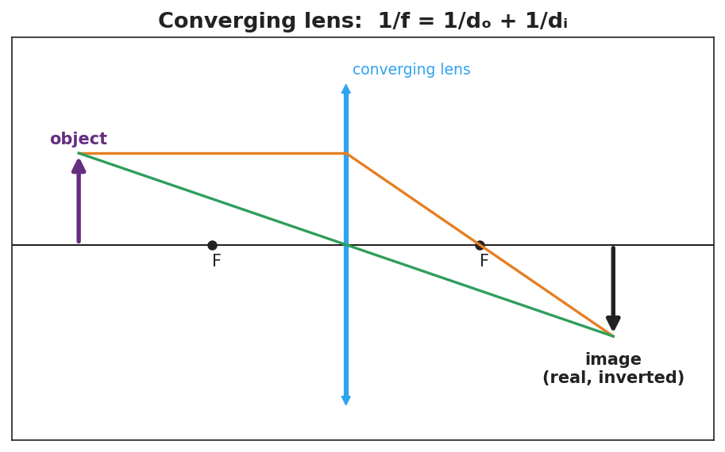

A converging-lens ray diagram: an object beyond F, the parallel ray refracting through the far focus, the central ray going straight, meeting at a real, inverted image; labeled 1/f = 1/dₒ + 1/dᵢ.

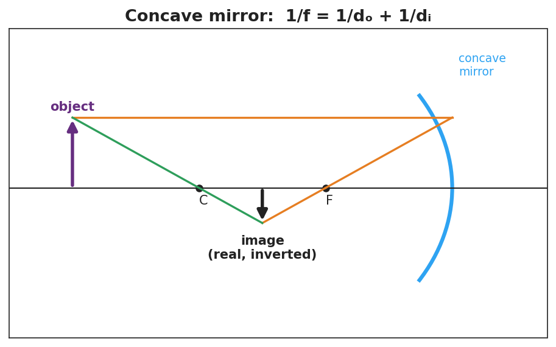

### Teacher facilitation during Explore

- **What to look for** — groups connecting “object inside f → no image on the screen” to “virtual image” (cannot be projected).
- **What to resist** — don’t give the equation first; let the (dₒ, dᵢ) data reveal the 1/f relationship.
- **What to redirect** — students who expect a screen image from a close object should be asked, “can you catch this image on paper, or only see it through the lens?”

## Phase 3 · Explain *(32 – 37 min)*

### 32–35 min · Turn-and-Talk #2 + class consensus

> “What decides whether you get a real (projectable) or virtual (look-through) image?”

Target consensus:

> “If the object is beyond the focal point, a converging lens or concave mirror forms a real, inverted image you can project. If the object is inside the focal length, the image is virtual, upright, and magnified — you can only see it by looking through.”

### 35–37 min · Vocabulary introduction (≤ 3 terms)

**Sample teacher language:**

> “The distance from the lens or mirror to its focus is the **focal length**, f. A lens that brings parallel rays together is a **converging lens** (and a concave mirror converges too). What forms where the rays meet — or appear to meet — is the **image**, related by 1/f = 1/dₒ + 1/dᵢ.”

### Discussion prompts to deploy here

- “An object is 30 cm from a converging lens with f = 10 cm. Where is the image?”
  - *Sample student response:* “1/dᵢ = 1/f − 1/dₒ = 1/10 − 1/30 = 1/15 → dᵢ = 15 cm (real, inverted).”
- “Why can’t you project the magnified image from a magnifying glass onto a wall?”
  - *Sample student response:* “It’s a virtual image — the rays don’t actually meet, so there’s nothing to catch on a screen.”

## Phase 4 · Elaborate *(37 – 40 min)*

### 37–39 min · Revise the model

> *“Return to your candle sketch. Re-draw both cases with the three principal rays. Label one image *real, inverted* and one *virtual, upright*. Note where the focal point F is.”*

### 39–40 min · Return to the phenomenon

> “Explain in one sentence why the magnifier’s image flips when you move it far from the page, using *focal length* and *image*.”

Target: “When the page is closer than the focal length the image is virtual and upright (magnified), but when the page is beyond the focal length the rays cross and form a real, inverted image — so it flips.”

## Phase 5 · Evaluate *(40 – 42 min)*

### 40–42 min · Exit Ticket + Closing Reflection

> *“A converging lens has a focal length of 12 cm. An object is placed 36 cm from the lens. (a) Use 1/f = 1/dₒ + 1/dᵢ to find the image distance. Show your work. (b) Is the image real or virtual? Upright or inverted? (c) If the object is moved to 6 cm (inside the focal length), can the image be projected on a screen? Why or why not?”*

Expected: (a) 1/dᵢ = 1/12 − 1/36 = 1/18 → dᵢ = 18 cm; (b) real and inverted (object beyond f); (c) no — inside f the image is virtual and cannot be projected. See `Answer_Key.docx`.

**Closing Reflection (SEL, 30 seconds):**

> “What’s one device with a lens or mirror you now understand better, and who helped you trace the rays?”

## Common Misconceptions

- **Misconception:** “A bigger lens always magnifies more.” → **Correction:** Magnification depends on the focal length and object distance, not the lens diameter.
- **Misconception:** “All images can be projected on a screen.” → **Correction:** Only *real* images (rays actually meet) project; virtual images (rays only appear to meet) cannot.
- **Misconception:** “Converging and concave mean opposite things.” → **Correction:** A *converging lens* and a *concave mirror* both bring parallel rays to a focus; they converge light.

## Access & Differentiation

- **ELL/ENL supports:** Sentence frame: *“When the object is ______ the focal length, the image is ______ (real/virtual) and ______ (upright/inverted).”* Word-choice box: {beyond, inside, real, virtual, upright, inverted}. Provide a labeled ray-diagram template.
- **IEP/SPED supports:** Provide pre-drawn principal axes with F marked; students draw only the two easiest rays (parallel and central). Give a 1/f = 1/dₒ + 1/dᵢ template with the unknown isolated and a worked example beside it.
- **Extensions:** Diverging lenses and convex mirrors always form reduced, upright, virtual images. Explain why a convex (passenger-side) car mirror is labeled “objects are closer than they appear.”

## Strategy Spotlight

**ACTIVE LEARNING.** Students physically place objects, hunt for the sharp image on a screen, and discover that a close object yields *no* screen image (a virtual image) before any term is introduced. Tracing the three principal rays by hand on the diagram cements the geometry. Facilitate with one prompt during the hunt: *“Can you catch this image on paper, or only see it through the lens?”* — separating real from virtual by experience.

## NYSSLS Observation Checklist Crosswalk

[output not shown]

## Companion Materials

- `Student_Worksheet.docx` — the 5E student investigation (hand out at start of Phase 2)
- `Student_Notes.docx` — guided note-guide for vocabulary and the worked example
- `Answer_Key.docx` — answers to “Make It Make Sense” prompts and the Exit Ticket

## Key Vocabulary (max 3)

- **focal length** — the distance (f) from a lens or mirror to its focal point, where parallel rays converge
- **converging lens** — a lens (thicker in the middle) that brings parallel rays together at the focal point; a concave mirror does the same by reflection
- **image** — the reproduction of an object formed by a lens or mirror; *real* if rays actually meet (projectable), *virtual* if they only appear to meet